# Report: act_report

This report presents communication of the insights and display the visualizations produced from the wrangled data. In particular, we aimed to address the following insights:

1. Among the breed of dogs based on the third prediction, what was the main sources of favorite count?
2. Among the breed of dogs based on the third prediction, what are the top 5 liked dogs?
3. Among the breed of dogs based on the third prediction, is there a relationship between favorite count and retweet count?
4. Among the breeds of dog based on the third prediction, what dog stage were the most retweeted?

We also plotted a pie chart to visualize the percentage composition of the dog stage.

```python
# import the required libraries
import pandas as pd
import numpy as np
import matplotlib.pyplot as plt
import seaborn as sns
%matplotlib inline
```

```python
#Read the master dataset
df = pd.read_csv("twitter_archive_master.csv")
```

```python
#view the first two rows of the dataset
df.head(2)
```

|  | tweet_id | timestamp | source | text | expanded_urls | rating_numerator | rating_denominator | dog_name | dog_stage | jpg_url | ... | p1_conf | p1_dog | p2 | p2_conf | p2_dog | p3 | p3_conf | p3_dog | retweet_count | favorite_count |
| --- | --- | --- | --- | --- | --- | --- | --- | --- | --- | --- | --- | --- | --- | --- | --- | --- | --- | --- | --- | --- | --- |
| 0 | 892420643555336193 | 2017-08-01 16:23:56+00:00 | iphone | This is Phineas. He's a mystical boy. Only eve... | https://twitter.com/dog_rates/status/892420643... | 13 | 10 | Phineas | NaN | https://pbs.twimg.com/media/DGKD1-bXoAAIAUK.jpg | ... | 0.097049 | False | bagel | 0.085851 | False | banana | 0.076110 | False | 8853 | 39467 |
| 1 | 892177421306343426 | 2017-08-01 00:17:27+00:00 | iphone | This is Tilly. She's just checking pup on you.... | https://twitter.com/dog_rates/status/892177421... | 13 | 10 | Tilly | NaN | https://pbs.twimg.com/media/DGGmoV4XsAAUL6n.jpg | ... | 0.323581 | True | pekinese | 0.090647 | True | papillon | 0.068957 | True | 6514 | 33819 |

2 rows × 22 columns

### Insight 1: Among the breed of dogs based on the third prediction, what was the main sources of favorite count?

Based on the analysis, the main sources of favorite counts among the breeds of dogs in the third prediction was iphone, followed by web client and then, tweetdeck. This implies most of the people who liked the breeds of dogs were iphone users.

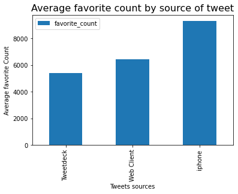

```python
#identify the relationship between dog stage and favorite count
df.query('p3_dog==True').groupby('source')['favorite_count'].mean().plot(kind='bar')
plt.title('Average favorite count by source of tweet', {'fontsize': 16})
plt.xlabel('Tweets sources')
plt.ylabel('Average favorite Count')
plt.legend()
plt.show;
```

### Insight 2: Among the breed of dogs based on the third prediction, what are the top 5 liked dogs?

```python
#top 5 liked dogs
df.query('p3_dog==True').groupby('dog_name')['favorite_count'].mean().sort_values(ascending=False).head(5)
```

```
dog_name
Duddles    107956.0
Stephan    107015.0
Jamesy     106827.0
Lilly       73397.0
Aja         71144.0
Name: favorite_count, dtype: float64
```

To identify the top 5 liked dogs, we filtered only those dogs identified as breeds of dogs in the dog prediction. We then grouped the data by dog name and computed the mean of the dogs in descending order. The results showed that the top 5 liked dogs were Duddles, stephan, Jamesy, Lilly, amd Aja. To gain more insights about the most liked dogs, we visualized the top 10 liked dogs below:

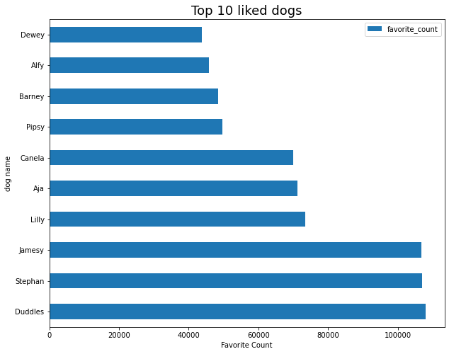

```python
#visualize top 10 liked dogs
df.query('p3_dog==True').groupby('dog_name')['favorite_count'].mean().sort_values(ascending=False).head(10).plot(kind='barh', figsize=(10,8))
plt.title('Top 10 liked dogs', {'fontsize':18})
plt.xlabel('Favorite Count')
plt.ylabel('dog name')
plt.legend()
plt.show();
```

### Insight 3: Among the breeds of dogs based on the third prediction, is there a relationship between favorite count and retweet count?

To get insights into whether there is a relationship between favorite count and retweet count, we used the third prediction to filter only the breeds of dogs. We then visualized the relationship using a scatter plot. The results showed that there was a strong positive linear relationship between favorite count and retweet count. This implies that as the favorite counts increases, the number of retweets increases. That is, the most liked dogs were more likely to be retweeted and vice versa.

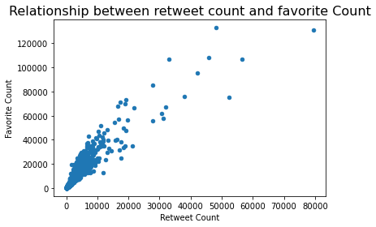

```python
## relationship between numerator rating and favorite count
df.query('p3_dog==True').plot(x ="retweet_count", y ="favorite_count", kind='scatter')
plt.title('Relationship between retweet count and favorite Count', {'fontsize':16})
plt.xlabel('Retweet Count')
plt.ylabel('Favorite Count')
plt.show();
```

### Insight 4: Among the breeds of dog based on the third prediction, what dog stage were the most retweeted?

To gain insights into what stage of dog were the most retweeted, we filtered the breeds of dogs based on the third prediction and visualized the retweet count among the four dog stages. The results revealed that dogs in the doggo stage were the most retweeted and possibly the most liked dogs. They were closey followed by the puppo and floof. However, dogs in the pupper stage were the least retweet dogs, and possibly the least liked dog stage.

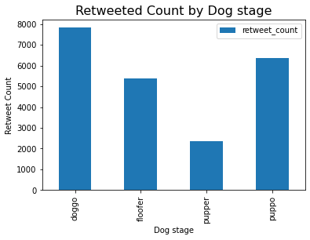

```python
df.query('p3_dog == True').groupby('dog_stage')['retweet_count'].mean().plot(kind="bar")
plt.legend()
plt.title('Retweeted Count by Dog stage', {'fontsize': 16})
plt.xlabel('Dog stage')
plt.ylabel('Retweet Count')
plt.show();
```

### Visualization

We plotted a pie chart to understand the distribution of dog stages in the clean data. The results showed that the highest percentage of the dogs 68.6% were from the pupper stage.In addition, 21.5% of the dogs were in the doggo stage, and 7.5% were in the puppo stage. However, the smallest percentage of the dogs (2.4%) were from the floof stage.

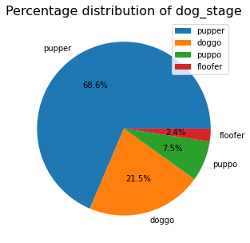

```python
#plot a pie chart to see the percentage composition of the dog stage in the sample.
((df.dog_stage.value_counts()/df.dog_stage.count())*100).plot.pie(figsize=(10,5),autopct='%1.1f%%')
plt.title('Percentage distribution of dog_stage', {'fontsize':16})
plt.ylabel('')
plt.legend()
plt.show();
```

```python
from subprocess import call
call(['python', '-m', 'nbconvert', 'act_report.ipynb'])
```

```
1
```